# Estudis d'Informàtica, Multimedia i Telecomunicacions

# Mineria de dades: PRA1 - Selecció i preparació d’un joc de dades

Autor: Cristina Espasa Cárdenas

Abril 2025

## 0.1 Enunciat

Tot estudi analític ha de néixer d’una necessitat per part del negoci o d’una voluntat de dotar-lo d’un coneixement i contingut en les dades que només podrem obtenir a través d’una col·lecció de bones pràctiques basades en la Mineria de Dades.

El món de l’analítica de dades es sustenta en 3 eixos:

1. Un d’ells és el profund **coneixement** que hauríem de tenir **del negoci** a què tractem de donar respostes mitjançant els estudis analítics.
2. L’altre gran eix és sens dubte les **capacitats analítiques** que siguem capaços de desplegar i en aquest sentit, les dues pràctiques d’aquesta assignatura pretenen que l’estudiant realitzi un recorregut sòlid per aquest segon eix.
3. El tercer eix són els **dades**. Les necessitats del negoci s’han de concretar amb preguntes analítiques que al seu torn siguin viables respondre a partir de les dades de què disposem. La tasca d’analitzar les dades és sens dubte important, però la tasca d’identificar-los i obtenir-los ha de ser per a un analista un repte permanent.

Com **primera part** de l’estudi analític que ens disposem a realitzar, es demana a l’estudiant que completi els següents passos:

1. Plantejar un problema de analítica de dades detallant-ne els objectius analítics i explica una metodologia per a resoldre’ls d’acord amb lo practicat en les PAC anteriors i també d’acord a lo que s’ha aprés en el material didàctic.
2. Seleccionar un joc de dades i justificar-ne l’elecció. El joc de dades **haurà de tenir capacitats** perquè se li puguin aplicar **algorismes supervisats** i **algorismes no supervisats** a la PRA2 i haurà d’estar alineat amb el problema analític plantejat al pas anterior.
- **Requisits mínims del conjunt de dades**:
  - Ha de ser diferent de qualsevol conjunt de dades utilitzat en les PAC anteriors.
  - No utilitzeu el conjunt de dades anomenat [German Credit Risk](https://www.kaggle.com/datasets/uciml/german-credit), ja que l’utilitzarem a la PAC3.
  - Ha de contenir almenys: 500 observacions, 5 variables numèriques, 2 variables categòriques i 1 variable binària. Entenem que trobar un conjunt de dades que compleixi exactament tots els criteris pot ser un repte. Per això, si un conjunt de dades és interessant i adequat per a l’anàlisi, però no compleix algun criteri puntual, es pot utilitzar justificant-ne l’elecció.

Adjuntem aquí una llista de portals de dades obertes per seleccionar el joc de dades. Es poden utilitzar altres fonts per obtenir el vostre joc de dades, però recordeu de citar-les:

- **Dades obertes**:
  - [Dades obertes Espanya](https://datos.gob.es/es/catalogo?q=&frequency=%7B%22type%22%3A+%22months%22%2C+%22value%22%3A+%221%22%7D&sort=score+desc%2C+metadata_modified+desc)
  - [Dades obertes Madrid](https://datos.madrid.es/portal/site/egob/)
  - [Dades obertes Barcelona](https://opendata-ajuntament.barcelona.cat/es/)
  - [Dades obertes Londres](https://data.london.gov.uk/)
  - [Dades obertes New York](https://opendata.cityofnewyork.us/)
- **Conjunts de dades per a aprenentatge automàtic i investigació**
  - [UCI Machine Learning](https://archive.ics.uci.edu/datasets?orderBy=DateDonated&sort=desc)
  - [Datasets for machine-learning research (Wikipedia)](https://en.wikipedia.org/wiki/List_of_datasets_for_machine-learning_research)
  - [Kaggle datasets](https://www.kaggle.com/datasets)
3. Realitzar una anàlisi exploratòria de el joc de dades seleccionat.
4. Realitzar tasques de neteja i condicionat per poder ser usat en processos de modelatge.
5. Realitzar mètodes de discretització
6. Aplicar un estudi PCA sobre el joc de dades. Tot i no estar explicat en el material didàctic, es valorarà si en lloc de PCA investigueu pel vostre compte i apliqueu SVD (Single Value Decomposition).
- **Alguns recursos**
  - [PCA per reducció de dimensions](https://www.aprendemachinelearning.com/comprende-principal-component-analysis/)
  - [SVD Singular Value Decomposition](https://math.mit.edu/classes/18.095/2016IAP/lec2/SVD_Notes.pdf)

Per a totes les PRA **cal documentar** a cada apartat de l’exercici pràctic que s’ha fet, perquè s’ha fet i com s’ha fet. Així mateix, totes les decisions i conclusions hauran de ser presentades de forma raonada i clara, **contextualitzant els resultats**, és a dir, especificant tots i cadascun dels passos que s’hagin dut a terme per resoldre’ls. Finalment, incloeu una **conclusió final** resumint els resultats obtinguts en la pràctica i indiqueu eventuals **citacions bibliogràfiques**, fonts internes/externes i materials de recerca.

## 0.2 Recursos de programació

- Incloem en aquest apartat una llista de recursos de programació per a mineria de dades on podreu trobar exemples, idees i inspiració:
  - Material addicional del llibre: Minería de datos Modelos y Algoritmos
  - [Espai de recursos UOC per a ciència de dades](http://datascience.recursos.uoc.edu/)
  - [Cercador de codi R](https://rseek.org/)
  - [Col·lecció de cheatsheets en R](https://www.rstudio.com/resources/cheatsheets/)

# 1 Plantejament del problema

La salut mental dels estudiants és un tema crític en l’àmbit educatiu actual. Les altes exigències acadèmiques, la pressió laboral futura i els factors socioeconòmics poden generar estrès, ansietat i depressió. Aquest estudi busca identificar patrons i relacions entre variables acadèmiques, psicològiques i sociodemogràfiques per entendre millor els factors que afecten el benestar emocional dels estudiants.

Per aconseguir-ho, es plantegen diversos objectius. En primer lloc, descriurem com es distribueixen variables com el rendiment (CGPA), la pressió acadèmica o la presència de depressió. També mirarem si hi ha diferències segons el gènere, i com es relacionen variables com l’estrès financer o les hores d’estudi amb la salut emocional. A més, aplicarem tècniques com la reducció de dimensions (PCA) per identificar els factors més rellevants. Tot això es farà seguint una metodologia basada en l’anàlisi exploratòria de dades, la neteja i preparació del conjunt de dades, la discretització de variables contínues i l’aplicació de tècniques de mineria de dades.

# 2 Selecció i justificació del dataset

Per a aquest projecte s’ha escollit el Student Depression Dataset, disponible a la plataforma Kaggle (https://www.kaggle.com/datasets/adilshamim8/student-depression-dataset). Aquest conjunt de dades recull informació de gairebé 28.000 estudiants i inclou variables com el rendiment acadèmic (CGPA), factors psicològics (com la depressió, la pressió acadèmica o l’estrès financer) i dades demogràfiques (com l’edat, el gènere o la professió). Tracta un tema molt actual i rellevant, ja que la salut mental en l’àmbit educatiu és una preocupació creixent, i aquest conjunt ens permet analitzar-ho des d’una perspectiva basada en dades.

Aquest dataset és útil perquè ens permet aplicar diferents tècniques de mineria de dades. A més, compleix els requisits mínims exigits per a aquesta pràctica: té moltes observacions, diverses variables numèriques i categòriques, i una variable binària (la presència o no de depressió).

# 3 Càrrega i anàlisi exploratòria de dades

Abans de fer cap model, hem explorat com es distribueixen les dades. Aquesta fase ens ajuda a detectar valors extrems, desequilibris entre grups i possibles relacions entre variables, com ara entre rendiment i pressió acadèmica, o entre gènere i depressió.

```r
knitr::opts_chunk$set(echo = TRUE)
# Llibreries i dades
library(tidyverse)
```

```r
library(ggplot2)
dades <- read_csv("student_depression_dataset.csv", show_col_types = FALSE)
# Resum
summary(dades)
```

```
##        id            Gender               Age            City
##  Min.   :     2   Length:27901       Min.   :18.00   Length:27901
##  1st Qu.: 35039   Class :character   1st Qu.:21.00   Class :character
##  Median : 70684   Mode  :character   Median :25.00   Mode  :character
##  Mean   : 70442                      Mean   :25.82
##  3rd Qu.:105818                      3rd Qu.:30.00
##  Max.   :140699                      Max.   :59.00
##
##   Profession        Academic Pressure Work Pressure          CGPA
##  Length:27901       Min.   :0.000     Min.   :0.00000   Min.   : 0.000
##  Class :character   1st Qu.:2.000     1st Qu.:0.00000   1st Qu.: 6.290
##  Mode  :character   Median :3.000     Median :0.00000   Median : 7.770
##                     Mean   :3.141     Mean   :0.00043   Mean   : 7.656
##                     3rd Qu.:4.000     3rd Qu.:0.00000   3rd Qu.: 8.920
##                     Max.   :5.000     Max.   :5.00000   Max.   :10.000
##
##  Study Satisfaction Job Satisfaction   Sleep Duration     Dietary Habits
##  Min.   :0.000      Min.   :0.000000   Length:27901       Length:27901
##  1st Qu.:2.000      1st Qu.:0.000000   Class :character   Class :character
##  Median :3.000      Median :0.000000   Mode  :character   Mode  :character
##  Mean   :2.944      Mean   :0.000681
##  3rd Qu.:4.000      3rd Qu.:0.000000
##  Max.   :5.000      Max.   :4.000000
##
##     Degree          Have you ever had suicidal thoughts ? Work/Study Hours
##  Length:27901       Length:27901                          Min.   : 0.000
##  Class :character   Class :character                      1st Qu.: 4.000
##  Mode  :character   Mode  :character                      Median : 8.000
##                                                           Mean   : 7.157
##                                                           3rd Qu.:10.000
##                                                           Max.   :12.000
##
##  Financial Stress Family History of Mental Illness   Depression
##  Min.   :1.00     Length:27901                     Min.   :0.0000
##  1st Qu.:2.00     Class :character                 1st Qu.:0.0000
##  Median :3.00     Mode  :character                 Median :1.0000
##  Mean   :3.14                                      Mean   :0.5855
##  3rd Qu.:4.00                                      3rd Qu.:1.0000
##  Max.   :5.00                                      Max.   :1.0000
##  NA's   :3
```

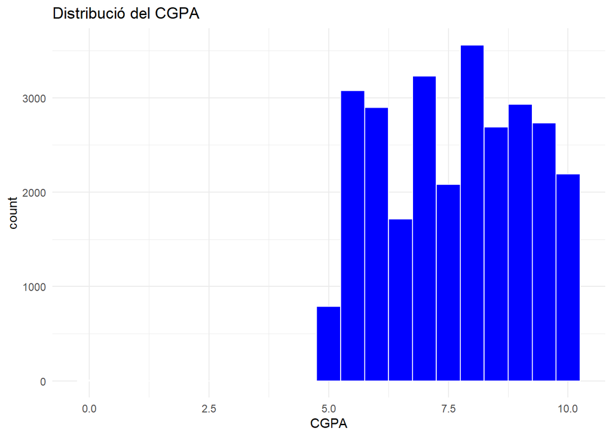

```r
knitr::opts_chunk$set(echo = TRUE)
# Distribució CGPA
ggplot(dades, aes(x = CGPA)) +
  geom_histogram(binwidth = 0.5, fill = "blue", color = "white") +
  ggtitle("Distribució del CGPA") +
  theme_minimal()
```

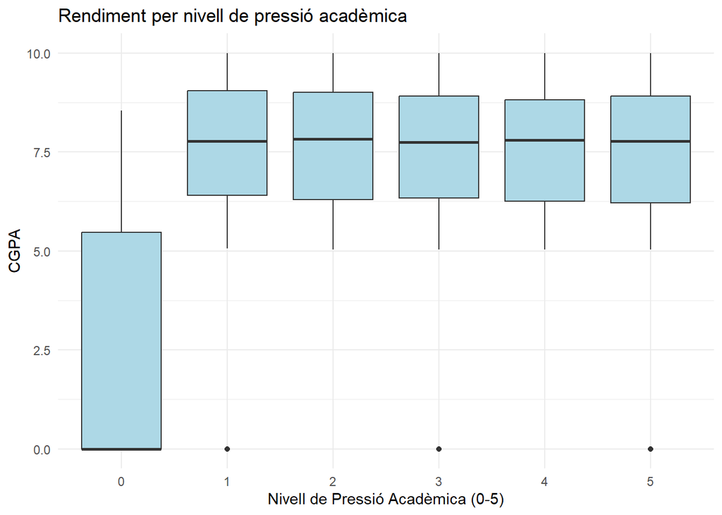

```r
# Relació pressió acadèmica vs. rendiment
ggplot(dades, aes(x = factor(`Academic Pressure`), y = CGPA)) +
  geom_boxplot(fill = "lightblue") +
  ggtitle("Rendiment per nivell de pressió acadèmica") +
  xlab("Nivell de Pressió Acadèmica (0-5)") +
  theme_minimal()
```

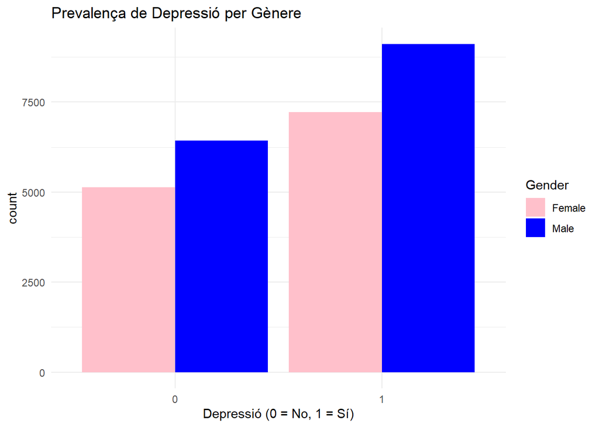

```r
# Depressió per gènere
ggplot(dades, aes(x = factor(Depression), fill = Gender)) +
  geom_bar(position = "dodge") +
  ggtitle("Prevalença de Depressió per Gènere") +
  xlab("Depressió (0 = No, 1 = Sí)") +
  scale_fill_manual(values = c("Male" = "blue", "Female" = "pink")) +
  theme_minimal()
```

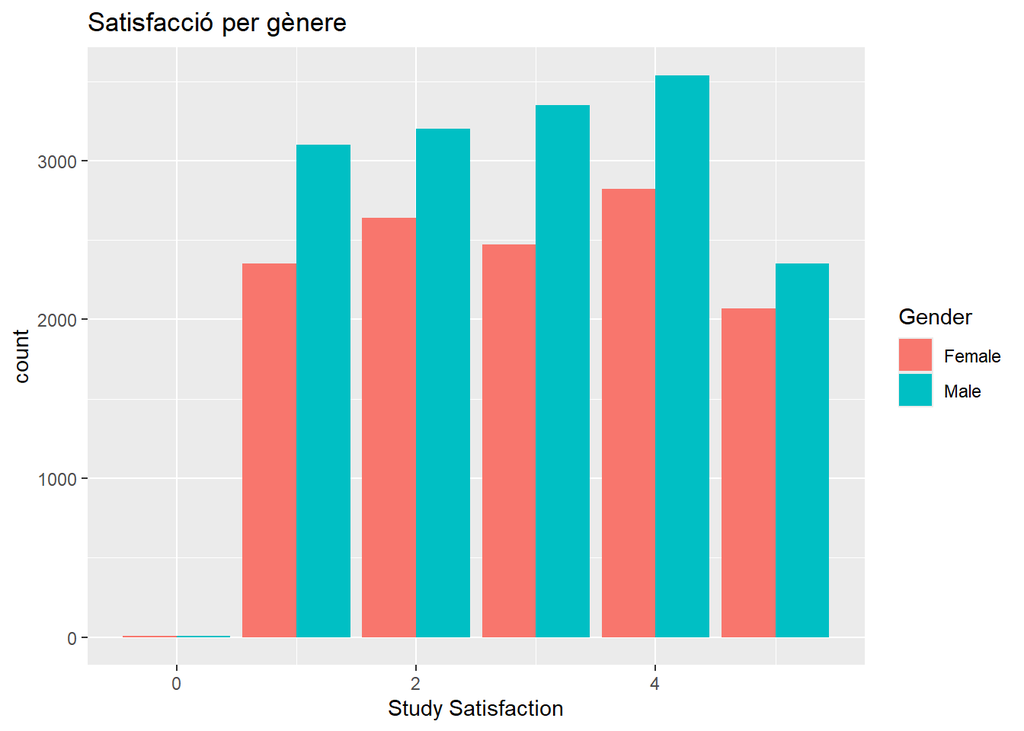

```r
knitr::opts_chunk$set(echo = TRUE)

ggplot(dades, aes(x = `Study Satisfaction`, fill = Gender)) +
  geom_bar(position = "dodge") +
  labs(title = "Satisfacció per gènere")
```

# 4 Neteja i condicionament

Abans d’aplicar qualsevol mètode analític, és imprescindible assegurar-se que les dades siguin consistents i estiguin en el format adequat. Aquesta fase inclou l’eliminació de valors nuls, el tractament de valors extrems (outliers), la transformació de variables i la conversió de columnes a tipus de dades adequats.

```r
knitr::opts_chunk$set(echo = TRUE)
# Tractament valors absents
dades <- dades %>%
  filter(!is.na(`Financial Stress`))

# Conversió a factors
dades <- dades %>%
  mutate(
    Depression = as.factor(Depression),
    `Have you ever had suicidal thoughts ?` = as.factor(`Have you ever had suicidal thoughts ?`),
    Gender = as.factor(Gender),
    `Sleep Duration` = as.factor(`Sleep Duration`)
  )

# Tractament outliers en CGPA
dades <- dades %>%
  filter(CGPA > 3 & CGPA < 10)  # Eliminar valors improbables
```

La neteja de les dades s’ha centrat en tres aspectes clau: la gestió dels valors absents, la codificació adequada de variables categòriques com factors, i l’eliminació d’outliers en variables numèriques crítiques com el CGPA.

L’eliminació de registres amb NA a l’estrès financer (només tres casos) no ha tingut un impacte rellevant en la mida de la mostra, però ha evitat possibles errors posteriors en càlculs estadístics. La conversió de variables com “Depression” o “Sleep Duration” en factors ha facilitat la seva gestió dins dels models. Finalment, la depuració de valors improbables al CGPA ha assegurat una millor qualitat de les anàlisis, evitant que els resultats es vegin distorsionats per dades errònies o extremadament rares.

# 5 Discretització de variables contínues

La discretització és una tècnica que consisteix a transformar variables contínues en categories. Aquesta transformació pot ser útil per a algorismes que no gestionen bé dades contínues o per millorar la interpretabilitat dels resultats. En aquest cas, s’ha aplicat a variables com el CGPA i l’edat, per agrupar els estudiants en rangs significatius des del punt de vista acadèmic i de vida.

```r
knitr::opts_chunk$set(echo = TRUE)
# Discretització CGPA
dades <- dades %>%
  mutate(
    CGPA_Category = cut(CGPA,
                       breaks = c(0, 6, 7.5, 9, 10),
                       labels = c("Baix", "Mitjà", "Alt", "Excel·lent"))
  )

# Discretització edat
dades <- dades %>%
  mutate(
    Age_Group = cut(Age,
                   breaks = c(17, 21, 25, 30, 35),
                   labels = c("17-21", "22-25", "26-30", "31-35"))
  )

# Taula freqüències per CGPA discretitzat
table(dades$CGPA_Category)
```

```
##
##       Baix      Mitjà        Alt Excel·lent
##       5556       7202       8899       6174
```

Al categoritzar variables contínues com el CGPA (en nivells Baix, Mitjà, Alt i Excel·lent) i l’edat (en grups de 17-21, 22-25, 26-30 i 31-35 anys) es permet comparar grups d’estudiants de manera més intuïtiva i identificar tendències en funció del rendiment o la franja d’edat. Per exemple, el 31% dels estudiants tenen un CGPA Alt (7.5-9), mentre que només el 22% estan en el nivell Excel·lent (9-10).

# 6 PCA (Principal Component Analysis)

Quan treballem amb moltes variables, pot ser difícil identificar les relacions més importants. El PCA (Anàlisi de Components Principals) és una tècnica estadística que redueix la dimensionalitat de les dades, condensant la informació en components principals que expliquen la major part de la variabilitat. Això simplifica les anàlisis posteriors i ajuda a detectar patrons subjacents que no són evidents a simple vista.

```r
knitr::opts_chunk$set(echo = TRUE)
# Selecció variables numèriques per PCA
numeric_vars <- dades %>%
  select(`Academic Pressure`, `Work/Study Hours`, CGPA, `Financial Stress`)

# Aplicació PCA
pca_result <- prcomp(numeric_vars, scale. = TRUE)

# Visualització
library(factoextra)
```

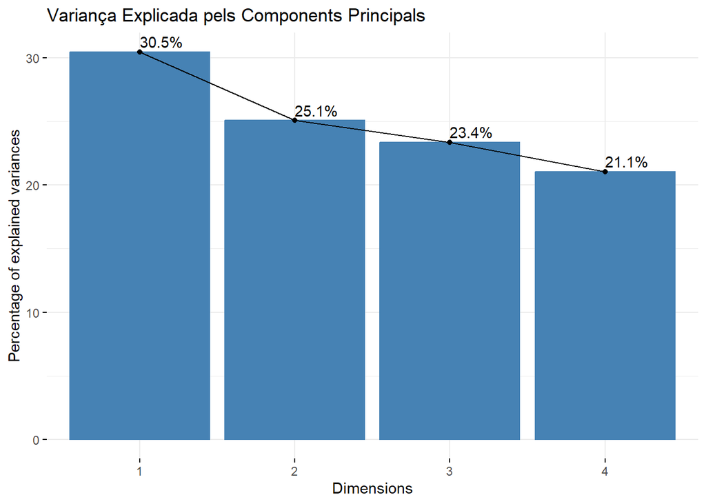

```r
fviz_eig(pca_result, addlabels = TRUE,
         main = "Variança Explicada pels Components Principals")
```

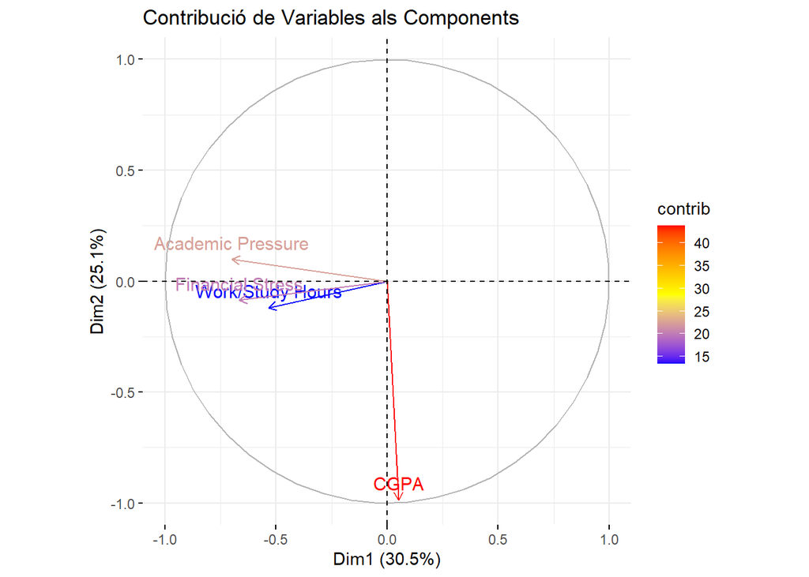

```r
fviz_pca_var(pca_result, col.var = "contrib",
             gradient.cols = c("blue", "yellow", "red"),
             title = "Contribució de Variables als Components")
```

# 7 Conclusió

Aquests resultats posen en relleu la necessitat d’equilibrar les exigències acadèmiques amb suports psicològics, especialment per a col·lectius vulnerables. Les institucions educatives podrien utilitzar aquestes dades per dissenyar estratègies que millorin tant el rendiment com el benestar estudiantil, com programes de gestió de l’estrès o assessorament personalitzat. Futures investigacions podrien també aprofundir en com factors com el son o les relacions socials interactuen amb aquestes variables per oferir una visió més completa de la salut mental a l’entorn acadèmic.